# HW3

Meng Cheng

11/4/2019

Load package

```r
rm(list = ls(all = TRUE))

library(igraph)
library(data.table)
library(reshape2)
library(MASS)
library(dplyr)
library(ggplot2)
library(plm)
```

Import data

```r
data1 <- fread("border_information.csv", header = TRUE)
data2 <- fread("district_information.csv", header = TRUE)
data3 <- fread("new_parties_in_each_district_by_candidate.csv", header = TRUE)
data4 <- fread("rain_information.csv", header = TRUE)
```

#Question 1 1. First, we will set up the relationship between rainfall and political party foundings, and then modify the rainfall measure to generate a statistically independent measure for droughts. This modiﬁcation will allow us to isolate the eﬀect of economic strain on political parties from other underlying features of a region that might inﬂuence its political structure. (A) Create a ﬁgure, for example, a scatter plot, showing the visual relationship between the level of rainfall in a district in the period leading up to the current election, and the number of political parties that are founded in a region. You can use the raw rainfall measure or the Standardized Precipitation Index. You can consider the level of rainfall for each election period in terms of (1) the sum of the raw rainfall during the interval starting from the year following the previous election up until the year of the current election or (2) the yearly average of the Standardized Precipitation Index during the interval starting from the year following the previous election up until the year of the current election.

```r
#check if all data have same time range
sort(unique(data2$year))
```

```
##  [1] 1951 1957 1962 1967 1971 1977 1980 1984 1985 1989 1991 1996 1998 1999
```

```r
sort(unique(data3$year))
```

```
##  [1] 1951 1957 1962 1967 1971 1977 1980 1984 1985 1989 1991 1996 1998 1999
```

```r
sort(unique(data4$year))
```

```
##  [1] 1946 1947 1948 1949 1950 1951 1952 1953 1954 1955 1956 1957 1958 1959
## [15] 1960 1961 1962 1963 1964 1965 1966 1967 1968 1969 1970 1971 1972 1973
## [29] 1974 1975 1976 1977 1978 1979 1980 1981 1982 1983 1984 1985 1986 1987
## [43] 1988 1989 1990 1991 1992 1993 1994 1995 1996 1997 1998 1999 2000 2001
## [57] 2002 2003
```

```r
#get all election year
electionyear<- sort(unique(data2$year))

#calculate election period each record belong to
changeyear <- function(x,yearlist) {
  i <- 1
  newx <- x
  while(i < length(yearlist)){
    if(x<yearlist[1]){
      newx <- yearlist[1]
      break
    }
    else if(x>yearlist[length(yearlist)]){
      newx <- 0
      break
    }
    else if(yearlist[i+1]>=x&yearlist[i]<x){
      newx <- yearlist[i+1]
      break
      }
    else{
      i = i + 1
    }
  }
  return(newx)
}

data4$adjyear <- apply(data4[,2], 1, changeyear, yearlist=electionyear)

#calculate sum rain and mean spi data for each election period by district
adjdata4 <- data4 %>%
  group_by(district,adjyear) %>%
  summarise(rain = sum(rain),spi = mean(spi))

names(adjdata4)[2]<-"year"

sort(unique(adjdata4$year))
```

```
##  [1]    0 1951 1957 1962 1967 1971 1977 1980 1984 1985 1989 1991 1996 1998
## [15] 1999
```

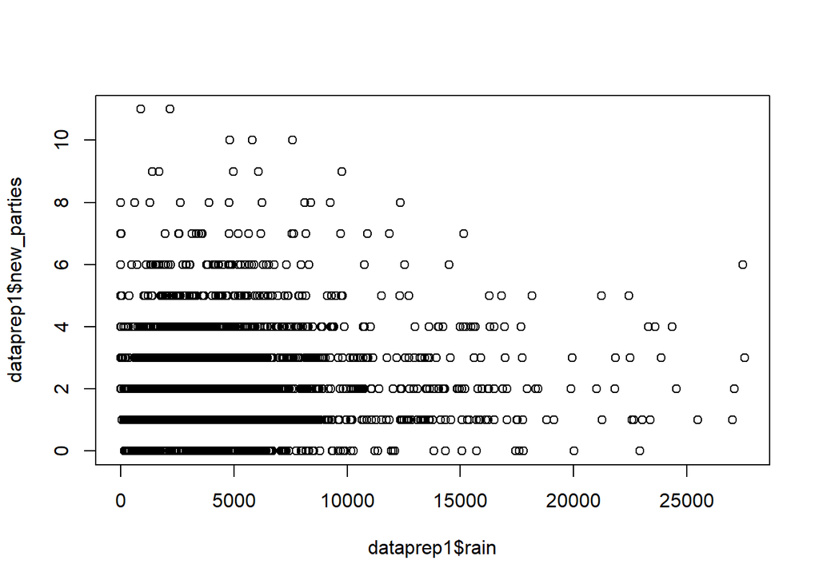

```r
#merge data table
dataprep1 <- merge(data2, adjdata4, by = c("district","year"), all = FALSE,
      sort = TRUE, suffixes = c(".x", ".y"), no.dups = TRUE,
      allow.cartesian= FALSE)

#for intuitive view, use both scatter plot and geom_smooth

#in terms of (1) the sum of the raw rainfall during the interval starting from the year following the previous election up until the year of the current election
plot(dataprep1$rain,dataprep1$new_parties)
```

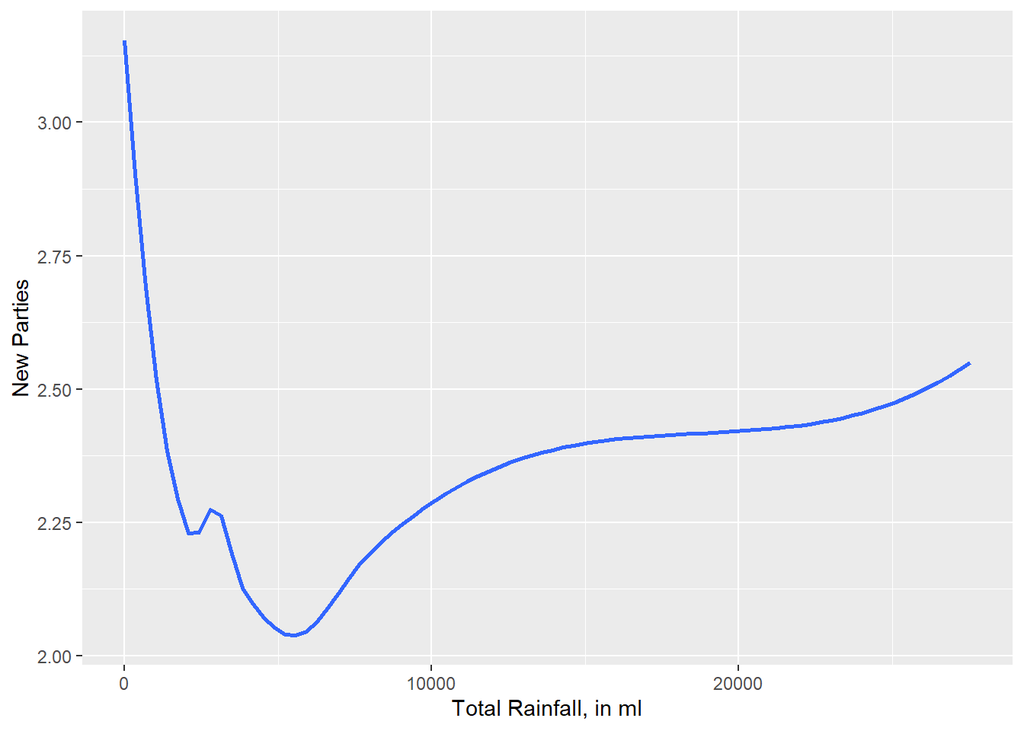

```r
ggplot(dataprep1, aes(rain, new_parties)) + geom_smooth(method = "loess", se = F) + labs(x = "Total Rainfall, in ml", y = "New Parties")
```

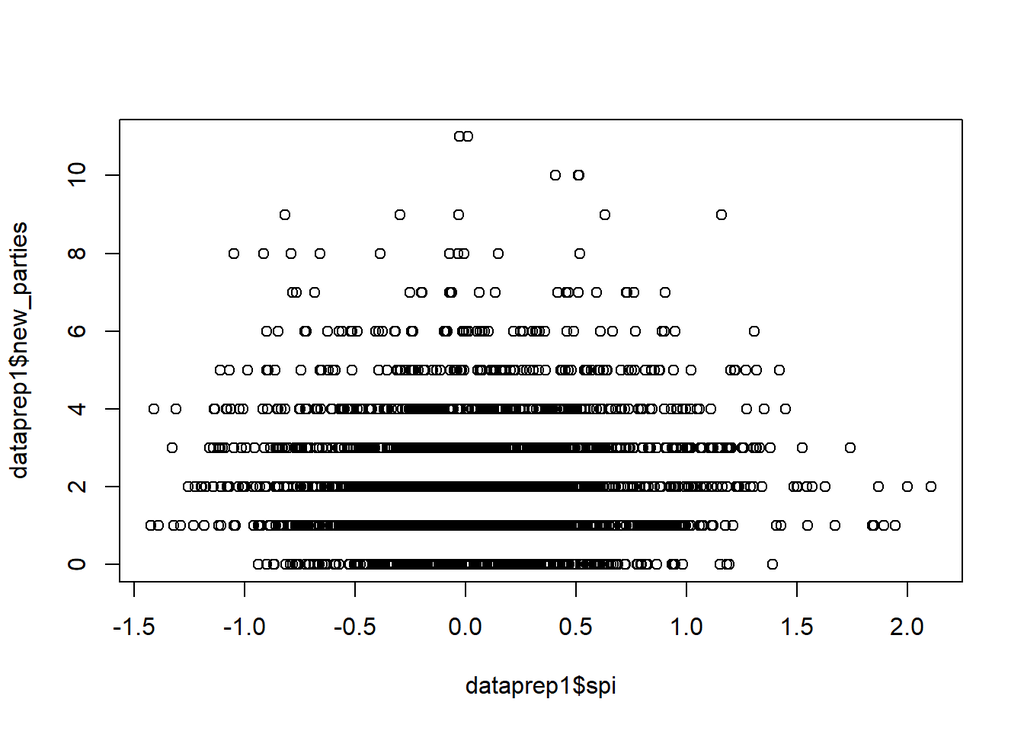

```r
#in terms of (2) the yearly average of the Standardized Precipitation Index during the interval starting from the year following the previous election up until the year of the current election
plot(dataprep1$spi,dataprep1$new_parties)
```

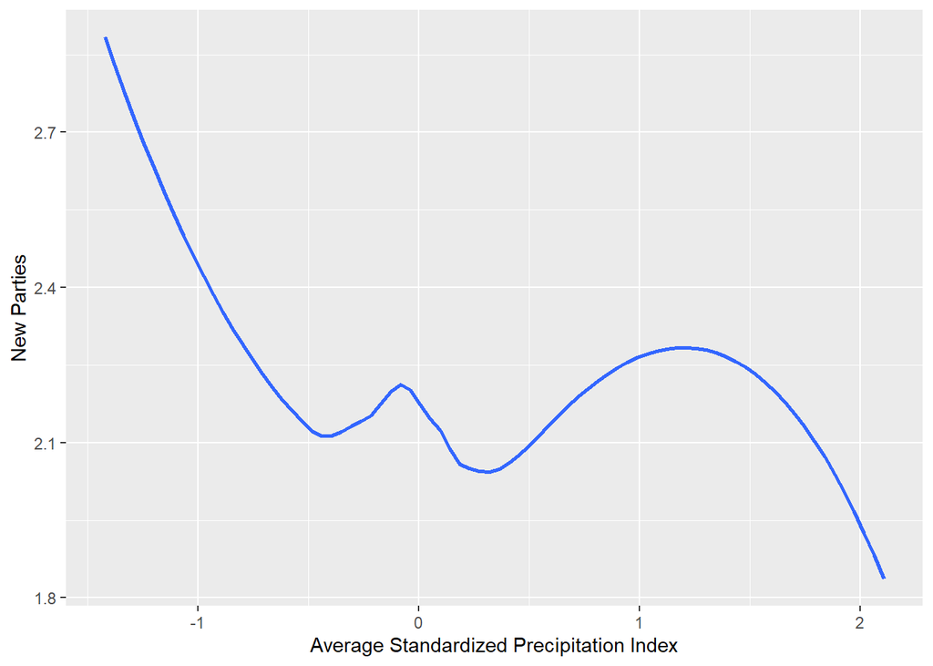

```r
ggplot(dataprep1, aes(spi, new_parties)) + geom_smooth(method = "loess", se = F) + labs(x = "Average Standardized Precipitation Index", y = "New Parties")
```

2. Using the election-period level rainfall measures created above, show that the raw level of rainfall, as well as the Standardized Precipitation Index, are not independent from one election period to the next within a district, as well as from neighboring districts from one election period to the next. It is possible to show this relationship by regressing a district’s current level of the rainfall variable on (1) its lagged value and (2) the lagged value of its neighbors’ rainfall variable. For computing the neighbors’ value, you can use an average of each of the surrounding districts’ values. Include a control in the regression for the number of years in the election period,and use a ﬁxed effects specification to control for the time-invariant features of a district as well as a control for each election period. This can be accomplished using the plm package, using a model specified in the form of plm(outcome variable ∼ predictor variables, data, effect = “twoways”, model = “within”, index = “district”),where“twoways” “within” provide both sets of ﬁxed effects.

```r
#get network graph from border information
neigh <- graph.data.frame(data1,directed = FALSE)

#get non-isolated node list
uniquedistrict <- names(V(neigh))

#neighs <- adjacent_vertices(neigh, V(neigh))

#sort table and remove non-election year
adjdata4 <- setorder(adjdata4, district, year)
raindata <- adjdata4[adjdata4$year!=0,]
```

```r
#find neighbor value by district and year
for (i in 1:dim(raindata)[1]){
  x <- as.data.table(raindata[i,])
  if(x$district %in% uniquedistrict){
    neighlist <- neighbors(neigh,x$district)
    neighlist <- names(neighlist)
    rain_neigh_table <- raindata %>% filter(district %in% neighlist) %>% subset(year==x$year)
    rain_neigh <- mean(rain_neigh_table$rain)
    spi_neigh <- mean(rain_neigh_table$spi)
    raindata[i,5] <- rain_neigh
    raindata[i,6] <- spi_neigh
  }
}

names(raindata)[5]<-"rain_neigh"
names(raindata)[6]<-"spi_neigh"
```

```r
# apply lag value for both neighbour and self
raindata[order(raindata$district, raindata$year),]
```

```
## # A tibble: 4,833 x 6
## # Groups:   district [517]
##    district  year  rain     spi rain_neigh spi_neigh
##    <chr>    <dbl> <dbl>   <dbl>      <dbl>     <dbl>
##  1 Adilabad  1951 6171.  0.0790      4957.    0.0312
##  2 Adilabad  1957 6335.  0.203       5007.    0.0514
##  3 Adilabad  1962 5476.  0.461       4703.    0.496
##  4 Adilabad  1967 5102.  0.0115      3988.   -0.290
##  5 Adilabad  1971 3713. -0.425       3817.   -0.0611
##  6 Adilabad  1977 5703. -0.250       6692.   -0.0205
##  7 Adilabad  1980 3160.  0.169       3671.    0.304
##  8 Adilabad  1984 4320.  0.400       5238.    0.602
##  9 Adilabad  1985  934. -0.409       1201.    0.0576
## 10 Adilabad  1989 4015. -0.0681      4222.   -0.0724
## # ... with 4,823 more rows
```

```r
for(i in 1:(dim(raindata)[1]-1)){
  x1 <- as.data.table(raindata[i,])
  x2 <- as.data.table(raindata[i+1,])
  if((x1$district==x2$district)&(match(x1$year,electionyear)-match(x2$year,electionyear)==-1)){
    raindata[i+1,7] <- raindata[i,3]
    raindata[i+1,8] <- raindata[i,4]
    raindata[i+1,9] <- raindata[i,5]
    raindata[i+1,10] <- raindata[i,6]
  }
}

names(raindata)[7]<-"rain_lag"
names(raindata)[8]<-"spi_lag"
names(raindata)[9]<-"rain_neigh_lag"
names(raindata)[10]<-"spi_neigh_lag"
```

```r
#add control for the number of years in the election period

for(i in 1:(dim(raindata)[1]-1)){
  x <- as.data.table(raindata[i,])
  if(x$year==1957){
    raindata[i,11] = 6
  }
  else if(x$year==1962){
    raindata[i,11] = 5
  }
  else if(x$year==1967){
    raindata[i,11] = 5
  }
  else if(x$year==1971){
    raindata[i,11] = 4
  }
  else if(x$year==1977){
    raindata[i,11] = 6
  }
  else if(x$year==1980){
    raindata[i,11] = 3
  }
  else if(x$year==1984){
    raindata[i,11] = 4
  }
  else if(x$year==1985){
    raindata[i,11] = 1
  }
  else if(x$year==1989){
    raindata[i,11] = 4
  }
  else if(x$year==1991){
    raindata[i,11] = 2
  }
  else if(x$year==1996){
    raindata[i,11] = 5
  }
  else if(x$year==1998){
    raindata[i,11] = 2
  }
  else if(x$year==1999){
    raindata[i,11] = 1
  }
}

names(raindata)[11]<-"interval"
```

```r
#simplify data table and remove NA
raindatareg <- raindata[,c(1:4,7:11)]
raindatareg <- na.omit(raindatareg)
raindatareg <- as.data.frame(raindatareg)
```

plm - Linear models for panel data estimated using the lm function on transformed data. effect: the effects introduced in the model, one of “individual”, “time”, “twoways”, or “nested”, mode: estimation methods: pooled OLS (model = “pooling”), fixed effects (“within”), random effects (“random”), first–differences (“fd”), and between (“between”).

```r
p1 <- plm(spi ~ spi_neigh_lag+spi_lag+interval, data=raindatareg, effect= "twoways", mode="within", index= "district")
p2 <- plm(rain ~ rain_neigh_lag+rain_lag+interval, data=raindatareg, effect= "twoways",mode="within",index= "district")
summary(p1)
```

```
## Twoways effects Within Model
##
## Call:
## plm(formula = spi ~ spi_neigh_lag + spi_lag + interval, data = raindatareg,
##     effect = "twoways", model = "within", index = "district")
##
## Unbalanced Panel: n = 292, T = 12-13, N = 3731
##
## Residuals:
##      Min.   1st Qu.    Median   3rd Qu.      Max.
## -1.526425 -0.309175 -0.023308  0.286556  2.716289
##
## Coefficients:
##                 Estimate Std. Error t-value  Pr(>|t|)
## spi_neigh_lag -0.2413330  0.0403489 -5.9811 2.444e-09 ***
## spi_lag        0.3117177  0.0360507  8.6466 < 2.2e-16 ***
## interval      -0.0332861  0.0098252 -3.3878 0.0007124 ***
## ---
## Signif. codes:  0 '***' 0.001 '**' 0.01 '*' 0.05 '.' 0.1 ' ' 1
##
## Total Sum of Squares:    934.6
## Residual Sum of Squares: 909.63
## R-Squared:      0.026717
## Adj. R-Squared: -0.060264
## F-statistic: 31.3303 on 3 and 3424 DF, p-value: < 2.22e-16
```

```r
summary(p2)
```

```
## Twoways effects Within Model
##
## Call:
## plm(formula = rain ~ rain_neigh_lag + rain_lag + interval, data = raindatareg,
##     effect = "twoways", model = "within", index = "district")
##
## Unbalanced Panel: n = 292, T = 12-13, N = 3731
##
## Residuals:
##      Min.   1st Qu.    Median   3rd Qu.      Max.
## -7767.121  -590.530   -32.739   614.572  9128.573
##
## Coefficients:
##                   Estimate  Std. Error t-value  Pr(>|t|)
## rain_neigh_lag   -0.128564    0.027732  -4.636 3.685e-06 ***
## rain_lag          0.373809    0.027414  13.636 < 2.2e-16 ***
## interval       1400.384251   31.665589  44.224 < 2.2e-16 ***
## ---
## Signif. codes:  0 '***' 0.001 '**' 0.01 '*' 0.05 '.' 0.1 ' ' 1
##
## Total Sum of Squares:    1.2376e+10
## Residual Sum of Squares: 7695300000
## R-Squared:      0.37822
## Adj. R-Squared: 0.32266
## F-statistic: 694.272 on 3 and 3424 DF, p-value: < 2.22e-16
```

Call: plm(formula = spi ~ spi_neigh_lag + spi_lag + interval, data = raindatareg, effect = “twoways”, model = “within”, index = “district”)

Call: plm(formula = rain ~ rain_neigh_lag + rain_lag + interval, data = raindatareg, effect = “twoways”, model = “within”, index = “district”)

3. Meteorological scientists consider moderate droughts to occur if the Standardized Precipitation Index falls below -1, and moderate ﬂoods to occur if it rises above 1. Create a measure that sums the number of years a district experiences either moderate droughts or ﬂoods during the interval starting from the year following the previous election up until the year of the current election. Perform the same test as in (B), using this new transformed measure. This measure will form the basis for the predictors used in the remainder of the regressions in Questions 2-5. Since this is a count outcome that is reported as a discrete number of years, use a regression adopted for data of this form—this can be accomplished with the pglm package, using a model speciﬁed in the form of pglm(outcome variable ∼ predictor variables, data, effect = “twoways”, model = “within”, index = “district”, family = “poisson”). What differences do you see between the estimates?

```r
#calculate extrem weather (floods or droughts)
data4$extrem <- 0
data4$extrem[which(data4$spi < (-1))] <- 1
data4$extrem[which(data4$spi > (1))] <- 1
```

```r
#calculate count of extrem weather within an election period by district
adjdata4C <- data4 %>%
  group_by(district,adjyear) %>%
  summarise(extrem = sum(extrem))

names(adjdata4C)[2]<-"year"
adjdata4C <- setorder(adjdata4C, district, year)
raindataC <- adjdata4C[adjdata4C$year!=0,]
```

```r
#find neighbor value
for (i in 1:dim(raindataC)[1]){
  x <- as.data.table(raindataC[i,])
  if(x$district %in% uniquedistrict){
    neighlist <- neighbors(neigh,x$district)
    neighlist <- names(neighlist)
    rain_neigh_table <- raindataC %>% filter(district %in% neighlist) %>% subset(year==x$year)
    extrem_neigh <- mean(rain_neigh_table$extrem)
    raindataC[i,4] <- extrem_neigh
  }
}

names(raindataC)[4]<-"extrem_neigh"
```

```r
#apply lag value
raindataC[order(raindataC$district, raindataC$year),]
```

```
## # A tibble: 4,833 x 4
## # Groups:   district [517]
##    district  year extrem extrem_neigh
##    <chr>    <dbl>  <dbl>        <dbl>
##  1 Adilabad  1951      2        1.33
##  2 Adilabad  1957      2        1.5
##  3 Adilabad  1962      1        1.67
##  4 Adilabad  1967      0        0.667
##  5 Adilabad  1971      0        0.333
##  6 Adilabad  1977      3        2.5
##  7 Adilabad  1980      0        0.667
##  8 Adilabad  1984      2        2
##  9 Adilabad  1985      0        0.333
## 10 Adilabad  1989      0        0.833
## # ... with 4,823 more rows
```

```r
for(i in 1:(dim(raindataC)[1]-1)){
  x1 <- as.data.table(raindataC[i,])
  x2 <- as.data.table(raindataC[i+1,])
  if((x1$district==x2$district)&(match(x1$year,electionyear)-match(x2$year,electionyear)==-1)){
    raindataC[i+1,5] <- raindataC[i,3]
    raindataC[i+1,6] <- raindataC[i,4]
  }
}

names(raindataC)[5]<-"extrem_lag"
names(raindataC)[6]<-"extrem_neigh_lag"
```

```r
#add control for the number of years in the election period
for(i in 1:(dim(raindataC)[1]-1)){
  x <- as.data.table(raindataC[i,])
  if(x$year==1957){
    raindataC[i,7] = 6
  }
  else if(x$year==1962){
    raindataC[i,7] = 5
  }
  else if(x$year==1967){
    raindataC[i,7] = 5
  }
  else if(x$year==1971){
    raindataC[i,7] = 4
  }
  else if(x$year==1977){
    raindataC[i,7] = 6
  }
  else if(x$year==1980){
    raindataC[i,7] = 3
  }
  else if(x$year==1984){
    raindataC[i,7] = 4
  }
  else if(x$year==1985){
    raindataC[i,7] = 1
  }
  else if(x$year==1989){
    raindataC[i,7] = 4
  }
  else if(x$year==1991){
    raindataC[i,7] = 2
  }
  else if(x$year==1996){
    raindataC[i,7] = 5
  }
  else if(x$year==1998){
    raindataC[i,7] = 2
  }
  else if(x$year==1999){
    raindataC[i,7] = 1
  }
}

names(raindataC)[7]<-"interval"
```

```r
#remove NA and transform to data.frame for pglm regression
raindataregC <- raindataC
raindataregC <- na.omit(raindataregC)
raindataregC <- as.data.frame(raindataregC)
```

pglm - Estimation by maximum likelihood of glm (binomial and Poisson) and ‘glm-like’ models (Negbin and ordered) on longitudinal data pglm(outcome variable ∼ predictor variables, data, effect = “twoways”, model = “within”, index = “district”, family = “poisson”) family: the distribution to be used,

```r
library("pglm")
p3 <- pglm(extrem ~ extrem_lag + extrem_neigh_lag + interval, data=raindataregC, effect = "twoways", model = "within", index = "district", family = "poisson")
summary(p3)
```

```
## --------------------------------------------
## Maximum Likelihood estimation
## Newton-Raphson maximisation, 3 iterations
## Return code 1: gradient close to zero
## Log-Likelihood: -3520.804
## 3  free parameters
## Estimates:
##                  Estimate Std. error t value Pr(> t)
## extrem_lag       -0.03778    0.03005  -1.257   0.209
## extrem_neigh_lag  0.03557    0.03634   0.979   0.328
## interval          0.34167    0.01209  28.252  <2e-16 ***
## ---
## Signif. codes:  0 '***' 0.001 '**' 0.01 '*' 0.05 '.' 0.1 ' ' 1
## --------------------------------------------
```

#What differences do you see between the estimates? Both extrem_lag and extrem_neigh_lag are not significant in above regression, show that the occurance of moderate floods or droughts, are independent from one election period to the next within a district, as well as from neighboring districts from one election period to the next. The occurance of moderate floods or droughts don’t pass down while the pattern of raw level of rainfall, as well as the Standardized Precipitation Index pass down through neighbouring districts. Since the occurance of droughts and floods are independent, it could be a good measure predictor variable to model the diffusion of political activity. We indeed use this measure in following questions.

Question2 Next, let’s analyze whether there are more new political parties when droughts or ﬂoods occur. Run a regression predicting the number of new political parties that are formed as a function of the number of years a district experiences droughts or ﬂooding in the interval starting from the year following the previous election up until the year of the current election. The number of new political parties that enter a district is a discrete count outcome. However, it is likely that the rate of entry of political parties in any particular district in a particular period is also related, or“auto correlated”, overtime, to the rate of entry in the prior period’s of this district’s history. As a result, we will use a feasible generalized least squares estimator that can take into account district-speciﬁc autocorrelation. This can be accessed through the panelAR package using a model of the form panelAR(outcome variable ∼ predictor variables, data, panelVar, timeVar, autoCorr = “psar1”, panelCorrMethod = “phet”, rho.na.rm = TRUE). In this regression, we are specifying district ﬁxed effects through “phet” and panel-speciﬁc autocorrelation through “psar1”. Also include a control in the regression for the number of years in the election period and a linear control for each election year. In addition to modeling the effect of extreme weather on the overall entry of new parties, do certain kinds of political parties seem to be more likely than other kinds to be formed when a district experiences extreme weather?

```r
#merge final version
dataprep2 <- merge(data2, raindatareg, by = c("district","year"), all = TRUE,
      sort = TRUE, suffixes = c(".x", ".y"), no.dups = TRUE,
      allow.cartesian= TRUE)

dataprep3 <- merge(dataprep2, raindataregC, by = c("district","year"), all = TRUE,
      sort = TRUE, suffixes = c(".x", ".y"), no.dups = TRUE,
      allow.cartesian= TRUE)

dataprep3 <- dataprep3[,1:34]
names(dataprep3)[30]<-"interval"
```

panelAR - estimates linear models on panel data structures in the presence of AR(1)-type autocorrelation as well as panel heteroskedasticity and/or contemporaneous correlation.

panelAR(outcome variable ∼ predictor variables, data, panelVar, timeVar, autoCorr = “psar1”, panelCorrMethod = “phet”, rho.na.rm = TRUE)

panelVar: the column name of data that contains the panel ID. It cannot contain any NAs. May be set to NULL, in which case all observations are assumed to belong to the same unit. timeVar: the column of data that contains the time ID. It must be a vector of integers and cannot contain any NAs. Duplicate time observations per panel are not allowed. At least two time periods are required.

autoCorr: character string denoting structure of autocorrelation in the data: ar1 denotes AR(1)-type autocorrelation with a common correlation coefficient across all panels, [psar1 denotes AR(1)-type autocorrelation with a unique correlation coefficient for each panel], and none denotes no autocorrelation. Default: ar1.

panelCorrMethod: character string denoting method used for dealing with panel heteroskedasticity and/or correlation. none denotes homoskedasticity and no correlation across panels, [phet denotes a Huber-White style sandwich estimator for panel heteroskedasticity], pcse denotes panel-corrected standard errors that are robust to both heteroskedasticity and contemporaneous correlation across panels, pwls denotes that a panel weighted least squares procedure is to deal with panel heteroskedasticity, and parks means that Parks-Kmenta FGLS is used to estimate both panel heteroskedasticity and correlation. Default: none.

rho.na.rm: logical. If FALSE and ρ_i cannot be calculated for a panel, function returns error. If TRUE, ρ_is that are NA are ignored if calculating a common AR(1) coefficient or set to 0 if calculating panel-specific AR(1) coefficients. Default: FALSE.

```r
library('panelAR')
dataprep4 <- as.data.frame(dataprep3)
dataprep5 <- na.omit(dataprep4)
p4 <- panelAR(new_parties ~ extrem + interval, data=dataprep5, panelVar = "district", timeVar = "year", autoCorr = "psar1", panelCorrMethod = "phet", rho.na.rm = TRUE)
```

```
## The following units have non-consecutive observations. Use runs.analysis() on output for additional details: Adilabad, Ahmednagar, Ajmer, Akola, Alwar, Amravati, Anantapur, Anantnag, Angul, Araria, Bagalkot, Balaghat, Balangir, Bangalore, Banka, Banswara, Baramulla, Barmer, Barpeta, Bathinda, Beg…
```

```
## Setting panel-specific correlation to 0 for at least one panel because unable to estimate autocorrelation.
```

```r
summary(p4)
```

```
##
## Panel Regression with AR(1) Prais-Winsten correction and panel heteroskedasticity-robust standard errors
##
## Unbalanced Panel Design:
##  Total obs.:       2295 Avg obs. per panel 10.5275
##  Number of panels: 218  Max obs. per panel 12
##  Number of times:  13   Min obs. per panel 1
##
## Coefficients:
##             Estimate Std. Error t value Pr(>|t|)
## (Intercept)  2.57406    0.07554  34.073  < 2e-16 ***
## extrem       0.09995    0.03209   3.115  0.00186 **
## interval    -0.16738    0.01991  -8.405  < 2e-16 ***
## ---
## Signif. codes:  0 '***' 0.001 '**' 0.01 '*' 0.05 '.' 0.1 ' ' 1
##
## R-squared: 0.2257
## Wald statistic: 70.9358, Pr(>Chisq(2)): 0
```

```r
#specific kind of party
p41 <- panelAR(new_parties_caste ~ extrem + interval, data=dataprep5, panelVar = "district", timeVar = "year", autoCorr = "psar1", panelCorrMethod = "phet", rho.na.rm = TRUE)
```

```
## The following units have non-consecutive observations. Use runs.analysis() on output for additional details: Adilabad, Ahmednagar, Ajmer, Akola, Alwar, Amravati, Anantapur, Anantnag, Angul, Araria, Bagalkot, Balaghat, Balangir, Bangalore, Banka, Banswara, Baramulla, Barmer, Barpeta, Bathinda, Beg…
## Setting panel-specific correlation to 0 for at least one panel because unable to estimate autocorrelation.
```

```r
summary(p41)
```

```
##
## Panel Regression with AR(1) Prais-Winsten correction and panel heteroskedasticity-robust standard errors
##
## Unbalanced Panel Design:
##  Total obs.:       2295 Avg obs. per panel 10.5275
##  Number of panels: 218  Max obs. per panel 12
##  Number of times:  13   Min obs. per panel 1
##
## Coefficients:
##               Estimate Std. Error t value Pr(>|t|)
## (Intercept)  0.7184748  0.0251006  28.624   <2e-16 ***
## extrem       0.0009206  0.0108989   0.084    0.933
## interval    -0.1037447  0.0067554 -15.357   <2e-16 ***
## ---
## Signif. codes:  0 '***' 0.001 '**' 0.01 '*' 0.05 '.' 0.1 ' ' 1
##
## R-squared: 0.1464
## Wald statistic: 294.4344, Pr(>Chisq(2)): 0
```

```r
p42 <- panelAR(new_parties_socialist ~ extrem + interval, data=dataprep5, panelVar = "district", timeVar = "year", autoCorr = "psar1", panelCorrMethod = "phet", rho.na.rm = TRUE)
```

```
## The following units have non-consecutive observations. Use runs.analysis() on output for additional details: Adilabad, Ahmednagar, Ajmer, Akola, Alwar, Amravati, Anantapur, Anantnag, Angul, Araria, Bagalkot, Balaghat, Balangir, Bangalore, Banka, Banswara, Baramulla, Barmer, Barpeta, Bathinda, Beg…
## Setting panel-specific correlation to 0 for at least one panel because unable to estimate autocorrelation.
```

```r
summary(p42)
```

```
##
## Panel Regression with AR(1) Prais-Winsten correction and panel heteroskedasticity-robust standard errors
##
## Unbalanced Panel Design:
##  Total obs.:       2295 Avg obs. per panel 10.5275
##  Number of panels: 218  Max obs. per panel 12
##  Number of times:  13   Min obs. per panel 1
##
## Coefficients:
##              Estimate Std. Error t value Pr(>|t|)
## (Intercept)  0.514452   0.030365  16.942  < 2e-16 ***
## extrem       0.033287   0.012721   2.617  0.00894 **
## interval    -0.046240   0.007968  -5.803  7.4e-09 ***
## ---
## Signif. codes:  0 '***' 0.001 '**' 0.01 '*' 0.05 '.' 0.1 ' ' 1
##
## R-squared: 0.0615
## Wald statistic: 33.6849, Pr(>Chisq(2)): 0
```

```r
p43 <- panelAR(new_parties_communist ~ extrem + interval, data=dataprep5, panelVar = "district", timeVar = "year", autoCorr = "psar1", panelCorrMethod = "phet", rho.na.rm = TRUE)
```

```
## The following units have non-consecutive observations. Use runs.analysis() on output for additional details: Adilabad, Ahmednagar, Ajmer, Akola, Alwar, Amravati, Anantapur, Anantnag, Angul, Araria, Bagalkot, Balaghat, Balangir, Bangalore, Banka, Banswara, Baramulla, Barmer, Barpeta, Bathinda, Beg…
## Setting panel-specific correlation to 0 for at least one panel because unable to estimate autocorrelation.
```

```r
summary(p43)
```

```
##
## Panel Regression with AR(1) Prais-Winsten correction and panel heteroskedasticity-robust standard errors
##
## Unbalanced Panel Design:
##  Total obs.:       2295 Avg obs. per panel 10.5275
##  Number of panels: 218  Max obs. per panel 12
##  Number of times:  13   Min obs. per panel 1
##
## Coefficients:
##              Estimate Std. Error t value Pr(>|t|)
## (Intercept)  0.290073   0.020877  13.894  < 2e-16 ***
## extrem      -0.009330   0.008861  -1.053  0.29245
## interval    -0.019775   0.005434  -3.639  0.00028 ***
## ---
## Signif. codes:  0 '***' 0.001 '**' 0.01 '*' 0.05 '.' 0.1 ' ' 1
##
## R-squared: 0.0508
## Wald statistic: 22.7782, Pr(>Chisq(2)): 0
```

```r
p44 <- panelAR(new_parties_secular ~ extrem + interval, data=dataprep5, panelVar = "district", timeVar = "year", autoCorr = "psar1", panelCorrMethod = "phet", rho.na.rm = TRUE)
```

```
## The following units have non-consecutive observations. Use runs.analysis() on output for additional details: Adilabad, Ahmednagar, Ajmer, Akola, Alwar, Amravati, Anantapur, Anantnag, Angul, Araria, Bagalkot, Balaghat, Balangir, Bangalore, Banka, Banswara, Baramulla, Barmer, Barpeta, Bathinda, Beg…
## Setting panel-specific correlation to 0 for at least one panel because unable to estimate autocorrelation.
```

```r
summary(p44)
```

```
##
## Panel Regression with AR(1) Prais-Winsten correction and panel heteroskedasticity-robust standard errors
##
## Unbalanced Panel Design:
##  Total obs.:       2295 Avg obs. per panel 10.5275
##  Number of panels: 218  Max obs. per panel 12
##  Number of times:  13   Min obs. per panel 1
##
## Coefficients:
##              Estimate Std. Error t value Pr(>|t|)
## (Intercept)  0.248649   0.018867  13.179  < 2e-16 ***
## extrem       0.017923   0.007247   2.473   0.0135 *
## interval    -0.026872   0.004675  -5.747 1.03e-08 ***
## ---
## Signif. codes:  0 '***' 0.001 '**' 0.01 '*' 0.05 '.' 0.1 ' ' 1
##
## R-squared: 0.0498
## Wald statistic: 33.0871, Pr(>Chisq(2)): 0
```

```r
p45 <- panelAR(new_parties_nationalist ~ extrem + interval, data=dataprep5, panelVar = "district", timeVar = "year", autoCorr = "psar1", panelCorrMethod = "phet", rho.na.rm = TRUE)
```

```
## The following units have non-consecutive observations. Use runs.analysis() on output for additional details: Adilabad, Ahmednagar, Ajmer, Akola, Alwar, Amravati, Anantapur, Anantnag, Angul, Araria, Bagalkot, Balaghat, Balangir, Bangalore, Banka, Banswara, Baramulla, Barmer, Barpeta, Bathinda, Beg…
## Setting panel-specific correlation to 0 for at least one panel because unable to estimate autocorrelation.
```

```r
summary(p45)
```

```
##
## Panel Regression with AR(1) Prais-Winsten correction and panel heteroskedasticity-robust standard errors
##
## Unbalanced Panel Design:
##  Total obs.:       2295 Avg obs. per panel 10.5275
##  Number of panels: 218  Max obs. per panel 12
##  Number of times:  13   Min obs. per panel 1
##
## Coefficients:
##             Estimate Std. Error t value Pr(>|t|)
## (Intercept) 0.108324   0.016333   6.632 4.11e-11 ***
## extrem      0.001779   0.006721   0.265  0.79131
## interval    0.012259   0.004188   2.927  0.00345 **
## ---
## Signif. codes:  0 '***' 0.001 '**' 0.01 '*' 0.05 '.' 0.1 ' ' 1
##
## R-squared: 0.0624
## Wald statistic: 11.2794, Pr(>Chisq(2)): 0.0036
```

```r
#There's no new_parties_economic==1
#p46 <- panelAR(new_parties_economic ~ extrem + interval, data=dataprep5, panelVar = "district", timeVar = "year", autoCorr = "psar1", panelCorrMethod = "phet", rho.na.rm = TRUE)
#summary(p46)

p47 <- panelAR(new_parties_religious ~ extrem + interval, data=dataprep5, panelVar = "district", timeVar = "year", autoCorr = "psar1", panelCorrMethod = "phet", rho.na.rm = TRUE)
```

```
## The following units have non-consecutive observations. Use runs.analysis() on output for additional details: Adilabad, Ahmednagar, Ajmer, Akola, Alwar, Amravati, Anantapur, Anantnag, Angul, Araria, Bagalkot, Balaghat, Balangir, Bangalore, Banka, Banswara, Baramulla, Barmer, Barpeta, Bathinda, Beg…
## Setting panel-specific correlation to 0 for at least one panel because unable to estimate autocorrelation.
```

```r
summary(p47)
```

```
##
## Panel Regression with AR(1) Prais-Winsten correction and panel heteroskedasticity-robust standard errors
##
## Unbalanced Panel Design:
##  Total obs.:       2295 Avg obs. per panel 10.5275
##  Number of panels: 218  Max obs. per panel 12
##  Number of times:  13   Min obs. per panel 1
##
## Coefficients:
##              Estimate Std. Error t value Pr(>|t|)
## (Intercept)  0.119000   0.016674   7.137 1.28e-12 ***
## extrem       0.005286   0.004109   1.287    0.198
## interval    -0.003610   0.003117  -1.158    0.247
## ---
## Signif. codes:  0 '***' 0.001 '**' 0.01 '*' 0.05 '.' 0.1 ' ' 1
##
## R-squared: 0.0723
## Wald statistic: 2.0891, Pr(>Chisq(2)): 0.3519
```

```r
p48 <- panelAR(new_parties_ethnic ~ extrem + interval, data=dataprep5, panelVar = "district", timeVar = "year", autoCorr = "psar1", panelCorrMethod = "phet", rho.na.rm = TRUE)
```

```
## The following units have non-consecutive observations. Use runs.analysis() on output for additional details: Adilabad, Ahmednagar, Ajmer, Akola, Alwar, Amravati, Anantapur, Anantnag, Angul, Araria, Bagalkot, Balaghat, Balangir, Bangalore, Banka, Banswara, Baramulla, Barmer, Barpeta, Bathinda, Beg…
## Setting panel-specific correlation to 0 for at least one panel because unable to estimate autocorrelation.
```

```r
summary(p48)
```

```
##
## Panel Regression with AR(1) Prais-Winsten correction and panel heteroskedasticity-robust standard errors
##
## Unbalanced Panel Design:
##  Total obs.:       2295 Avg obs. per panel 10.5275
##  Number of panels: 218  Max obs. per panel 12
##  Number of times:  13   Min obs. per panel 1
##
## Coefficients:
##              Estimate Std. Error t value Pr(>|t|)
## (Intercept)  0.252035   0.019260  13.086  < 2e-16 ***
## extrem      -0.005604   0.008189  -0.684    0.494
## interval    -0.024894   0.005131  -4.851 1.31e-06 ***
## ---
## Signif. codes:  0 '***' 0.001 '**' 0.01 '*' 0.05 '.' 0.1 ' ' 1
##
## R-squared: 0.0493
## Wald statistic: 36.4904, Pr(>Chisq(2)): 0
```

```r
p49 <- panelAR(new_parties_farleft ~ extrem + interval, data=dataprep5, panelVar = "district", timeVar = "year", autoCorr = "psar1", panelCorrMethod = "phet", rho.na.rm = TRUE)
```

```
## The following units have non-consecutive observations. Use runs.analysis() on output for additional details: Adilabad, Ahmednagar, Ajmer, Akola, Alwar, Amravati, Anantapur, Anantnag, Angul, Araria, Bagalkot, Balaghat, Balangir, Bangalore, Banka, Banswara, Baramulla, Barmer, Barpeta, Bathinda, Beg…
## Setting panel-specific correlation to 0 for at least one panel because unable to estimate autocorrelation.
```

```r
summary(p49)
```

```
##
## Panel Regression with AR(1) Prais-Winsten correction and panel heteroskedasticity-robust standard errors
##
## Unbalanced Panel Design:
##  Total obs.:       2295 Avg obs. per panel 10.5275
##  Number of panels: 218  Max obs. per panel 12
##  Number of times:  13   Min obs. per panel 1
##
## Coefficients:
##             Estimate Std. Error t value Pr(>|t|)
## (Intercept)  0.74913    0.03875  19.332  < 2e-16 ***
## extrem       0.02790    0.01618   1.725   0.0848 .
## interval    -0.05741    0.01027  -5.588 2.57e-08 ***
## ---
## Signif. codes:  0 '***' 0.001 '**' 0.01 '*' 0.05 '.' 0.1 ' ' 1
##
## R-squared: 0.0793
## Wald statistic: 32.2964, Pr(>Chisq(2)): 0
```

```r
p410 <- panelAR(new_parties_farright ~ extrem + interval, data=dataprep5, panelVar = "district", timeVar = "year", autoCorr = "psar1", panelCorrMethod = "phet", rho.na.rm = TRUE)
```

```
## The following units have non-consecutive observations. Use runs.analysis() on output for additional details: Adilabad, Ahmednagar, Ajmer, Akola, Alwar, Amravati, Anantapur, Anantnag, Angul, Araria, Bagalkot, Balaghat, Balangir, Bangalore, Banka, Banswara, Baramulla, Barmer, Barpeta, Bathinda, Beg…
## Setting panel-specific correlation to 0 for at least one panel because unable to estimate autocorrelation.
```

```r
summary(p410)
```

```
##
## Panel Regression with AR(1) Prais-Winsten correction and panel heteroskedasticity-robust standard errors
##
## Unbalanced Panel Design:
##  Total obs.:       2295 Avg obs. per panel 10.5275
##  Number of panels: 218  Max obs. per panel 12
##  Number of times:  13   Min obs. per panel 1
##
## Coefficients:
##              Estimate Std. Error t value Pr(>|t|)
## (Intercept) -0.037837   0.013523  -2.798  0.00519 **
## extrem      -0.006131   0.005559  -1.103  0.27013
## interval     0.037290   0.003478  10.722  < 2e-16 ***
## ---
## Signif. codes:  0 '***' 0.001 '**' 0.01 '*' 0.05 '.' 0.1 ' ' 1
##
## R-squared: 0.0842
## Wald statistic: 129.1537, Pr(>Chisq(2)): 0
```

```r
p411 <- panelAR(new_parties_farming ~ extrem + interval, data=dataprep5, panelVar = "district", timeVar = "year", autoCorr = "psar1", panelCorrMethod = "phet", rho.na.rm = TRUE)
```

```
## The following units have non-consecutive observations. Use runs.analysis() on output for additional details: Adilabad, Ahmednagar, Ajmer, Akola, Alwar, Amravati, Anantapur, Anantnag, Angul, Araria, Bagalkot, Balaghat, Balangir, Bangalore, Banka, Banswara, Baramulla, Barmer, Barpeta, Bathinda, Beg…
## Setting panel-specific correlation to 0 for at least one panel because unable to estimate autocorrelation.
```

```r
summary(p411)
```

```
##
## Panel Regression with AR(1) Prais-Winsten correction and panel heteroskedasticity-robust standard errors
##
## Unbalanced Panel Design:
##  Total obs.:       2295 Avg obs. per panel 10.5275
##  Number of panels: 218  Max obs. per panel 12
##  Number of times:  13   Min obs. per panel 1
##
## Coefficients:
##              Estimate Std. Error t value Pr(>|t|)
## (Intercept)  0.139341   0.013753   10.13  < 2e-16 ***
## extrem       0.002235   0.002725    0.82 0.412127
## interval    -0.006978   0.001938   -3.60 0.000325 ***
## ---
## Signif. codes:  0 '***' 0.001 '**' 0.01 '*' 0.05 '.' 0.1 ' ' 1
##
## R-squared: 0.0923
## Wald statistic: 13.3507, Pr(>Chisq(2)): 0.0013
```

```r
p412 <- panelAR(new_parties_liberal ~ extrem + interval, data=dataprep5, panelVar = "district", timeVar = "year", autoCorr = "psar1", panelCorrMethod = "phet", rho.na.rm = TRUE)
```

```
## The following units have non-consecutive observations. Use runs.analysis() on output for additional details: Adilabad, Ahmednagar, Ajmer, Akola, Alwar, Amravati, Anantapur, Anantnag, Angul, Araria, Bagalkot, Balaghat, Balangir, Bangalore, Banka, Banswara, Baramulla, Barmer, Barpeta, Bathinda, Beg…
## Setting panel-specific correlation to 0 for at least one panel because unable to estimate autocorrelation.
```

```r
summary(p412)
```

```
##
## Panel Regression with AR(1) Prais-Winsten correction and panel heteroskedasticity-robust standard errors
##
## Unbalanced Panel Design:
##  Total obs.:       2295 Avg obs. per panel 10.5275
##  Number of panels: 218  Max obs. per panel 12
##  Number of times:  13   Min obs. per panel 1
##
## Coefficients:
##             Estimate Std. Error t value Pr(>|t|)
## (Intercept)  1.23684    0.05023  24.622   <2e-16 ***
## extrem      -0.01668    0.02255  -0.740     0.46
## interval    -0.13198    0.01362  -9.693   <2e-16 ***
## ---
## Signif. codes:  0 '***' 0.001 '**' 0.01 '*' 0.05 '.' 0.1 ' ' 1
##
## R-squared: 0.0943
## Wald statistic: 127.4965, Pr(>Chisq(2)): 0
```

For certain kinds of political parties(estimate of variable extrem): new_parties_caste 0.0009206

new_parties_socialist 0.033287**

new_parties_communist -0.009330

new_parties_secular 0.017923*

new_parties_nationalist 0.001779

new_parties_religious 0.005286

new_parties_ethnic -0.005604

new_parties_farleft 0.02790

new_parties_farright -0.006131

new_parties_farming 0.002235

new_parties_liberal -0.01668

Only entry of socialist and secular parties has variable extrem significant in regression and there are significant more new political parties when extrem weather occur for both types of parties. With estimate of 0.033287, socialist parties are especially more likely than other kinds to be formed when a district experiences extreme weather. It may due to the characteristics of this specific party that it focus more on well being of the people, thus socialist (as well as secular) parties are more likely to be triggered to form under extrem weather.

Question3 3. Now that we have established the baseline effect, we can look at how political activity stimulated by droughts or ﬂoods in one district might affect political activity in another district. Use a similar regression to Question2 to show that,even when taking into account a district’s own droughts and ﬂoods,the level of entry of new political parties in a district will also depend on the number of years its neighboring districts experience years of droughts or ﬂooding in the interval starting from the year following two elections ago, up until the year of the previous election—the election lead-up interval before the current one. Similar to Question 2, include a control in the regression for the number of years in the current election period, a control for the time-invariant features of a district as ﬁxed effects, and a linear control for each election year.

```r
p5 <- panelAR(new_parties ~ extrem + extrem_neigh_lag + interval, data=dataprep5, panelVar = "district", timeVar = "year", autoCorr = "psar1", panelCorrMethod = "phet", rho.na.rm = TRUE)
```

```
## The following units have non-consecutive observations. Use runs.analysis() on output for additional details: Adilabad, Ahmednagar, Ajmer, Akola, Alwar, Amravati, Anantapur, Anantnag, Angul, Araria, Bagalkot, Balaghat, Balangir, Bangalore, Banka, Banswara, Baramulla, Barmer, Barpeta, Bathinda, Beg…
```

```
## Setting panel-specific correlation to 0 for at least one panel because unable to estimate autocorrelation.
```

```r
summary(p5)
```

```
##
## Panel Regression with AR(1) Prais-Winsten correction and panel heteroskedasticity-robust standard errors
##
## Unbalanced Panel Design:
##  Total obs.:       2295 Avg obs. per panel 10.5275
##  Number of panels: 218  Max obs. per panel 12
##  Number of times:  13   Min obs. per panel 1
##
## Coefficients:
##                  Estimate Std. Error t value Pr(>|t|)
## (Intercept)       2.47826    0.08107  30.571  < 2e-16 ***
## extrem            0.10321    0.03200   3.225  0.00128 **
## extrem_neigh_lag  0.10872    0.03545   3.067  0.00219 **
## interval         -0.16974    0.01989  -8.536  < 2e-16 ***
## ---
## Signif. codes:  0 '***' 0.001 '**' 0.01 '*' 0.05 '.' 0.1 ' ' 1
##
## R-squared: 0.2325
## Wald statistic: 79.6855, Pr(>Chisq(3)): 0
```

Question4 4. Extreme weather events like droughts or floods can erode the stability of political systems and wear away at the entrenched power bases of large, national-scale parties that have diffculty responding to the needs of affected regions. (A) Does experiencing droughts or ﬂoods relate differently to the entry and diffusion of political parties depending on their scope? Perform regressions, similar to Question 3, one each predicting the entry of new national, state, and regional scope parties as the outcome based on extreme weather in a district in the period leading up to the current election and based on extreme weather in neighboring districts in the period leading up to the prior election. Include a control in the regression for the number of years in the election period, a control for the time-invariant features of a district, and a linear control for each election year.

```r
p6 <- panelAR(new_parties_national_scope ~ extrem + extrem_neigh_lag + interval, data=dataprep5, panelVar = "district", timeVar = "year", autoCorr = "psar1", panelCorrMethod = "phet", rho.na.rm = TRUE)
```

```
## The following units have non-consecutive observations. Use runs.analysis() on output for additional details: Adilabad, Ahmednagar, Ajmer, Akola, Alwar, Amravati, Anantapur, Anantnag, Angul, Araria, Bagalkot, Balaghat, Balangir, Bangalore, Banka, Banswara, Baramulla, Barmer, Barpeta, Bathinda, Beg…
```

```
## Setting panel-specific correlation to 0 for at least one panel because unable to estimate autocorrelation.
```

```r
summary(p6)
```

```
##
## Panel Regression with AR(1) Prais-Winsten correction and panel heteroskedasticity-robust standard errors
##
## Unbalanced Panel Design:
##  Total obs.:       2295 Avg obs. per panel 10.5275
##  Number of panels: 218  Max obs. per panel 12
##  Number of times:  13   Min obs. per panel 1
##
## Coefficients:
##                  Estimate Std. Error t value Pr(>|t|)
## (Intercept)       1.34443    0.05972  22.514   <2e-16 ***
## extrem            0.06019    0.02361   2.549   0.0109 *
## extrem_neigh_lag  0.23578    0.02431   9.698   <2e-16 ***
## interval         -0.10678    0.01212  -8.811   <2e-16 ***
## ---
## Signif. codes:  0 '***' 0.001 '**' 0.01 '*' 0.05 '.' 0.1 ' ' 1
##
## R-squared: 0.8026
## Wald statistic: 222.0951, Pr(>Chisq(3)): 0
```

```r
p7 <- panelAR(new_parties_state_scope ~ extrem + extrem_neigh_lag + interval, data=dataprep5, panelVar = "district", timeVar = "year", autoCorr = "psar1", panelCorrMethod = "phet", rho.na.rm = TRUE)
```

```
## The following units have non-consecutive observations. Use runs.analysis() on output for additional details: Adilabad, Ahmednagar, Ajmer, Akola, Alwar, Amravati, Anantapur, Anantnag, Angul, Araria, Bagalkot, Balaghat, Balangir, Bangalore, Banka, Banswara, Baramulla, Barmer, Barpeta, Bathinda, Beg…
## Setting panel-specific correlation to 0 for at least one panel because unable to estimate autocorrelation.
```

```r
summary(p7)
```

```
##
## Panel Regression with AR(1) Prais-Winsten correction and panel heteroskedasticity-robust standard errors
##
## Unbalanced Panel Design:
##  Total obs.:       2295 Avg obs. per panel 10.5275
##  Number of panels: 218  Max obs. per panel 12
##  Number of times:  13   Min obs. per panel 1
##
## Coefficients:
##                    Estimate Std. Error t value Pr(>|t|)
## (Intercept)       0.3584683  0.0269102  13.321  < 2e-16 ***
## extrem           -0.0001612  0.0092633  -0.017    0.986
## extrem_neigh_lag -0.0431358  0.0090773  -4.752 2.14e-06 ***
## interval         -0.0305640  0.0064923  -4.708 2.65e-06 ***
## ---
## Signif. codes:  0 '***' 0.001 '**' 0.01 '*' 0.05 '.' 0.1 ' ' 1
##
## R-squared: 0.0679
## Wald statistic: 46.4967, Pr(>Chisq(3)): 0
```

```r
p8 <- panelAR(new_parties_regional_scope ~ extrem + extrem_neigh_lag + interval, data=dataprep5, panelVar = "district", timeVar = "year", autoCorr = "psar1", panelCorrMethod = "phet", rho.na.rm = TRUE)
```

```
## The following units have non-consecutive observations. Use runs.analysis() on output for additional details: Adilabad, Ahmednagar, Ajmer, Akola, Alwar, Amravati, Anantapur, Anantnag, Angul, Araria, Bagalkot, Balaghat, Balangir, Bangalore, Banka, Banswara, Baramulla, Barmer, Barpeta, Bathinda, Beg…
## Setting panel-specific correlation to 0 for at least one panel because unable to estimate autocorrelation.
```

```r
summary(p8)
```

```
##
## Panel Regression with AR(1) Prais-Winsten correction and panel heteroskedasticity-robust standard errors
##
## Unbalanced Panel Design:
##  Total obs.:       2295 Avg obs. per panel 10.5275
##  Number of panels: 218  Max obs. per panel 12
##  Number of times:  13   Min obs. per panel 1
##
## Coefficients:
##                   Estimate Std. Error t value Pr(>|t|)
## (Intercept)       0.685986   0.045787  14.982  < 2e-16 ***
## extrem            0.002514   0.018281   0.137 0.890654
## extrem_neigh_lag -0.070851   0.020083  -3.528 0.000427 ***
## interval         -0.039959   0.011073  -3.609 0.000314 ***
## ---
## Signif. codes:  0 '***' 0.001 '**' 0.01 '*' 0.05 '.' 0.1 ' ' 1
##
## R-squared: 0.0494
## Wald statistic: 27.7762, Pr(>Chisq(3)): 0
```

#Does experiencing droughts or ﬂoods relate differently to the entry and diffusion of political parties depending on their scope? new_parties_national_scope extrem 0.06019*  
extrem_neigh_lag 0.23578***

new_parties_state_scope extrem -0.0001612  
extrem_neigh_lag -0.0431358***

new_parties_regional_scope extrem 0.002514 extrem_neigh_lag -0.070851***

With significant estimate on 95% confidence interval for extrem variable, national scope parties are the only kind of party that has positive entry and diffusion affected by extrem weather. It could be explained by that national scope has higher motivation to make effort to deal with extrem weather while regional and state scope parties don’t have the ability to respond in time. With highly significant estimate for extrem_neigh_lag variable, entry and diffusion of political parties are affected by extrem weather. However, only national scope parties receive positive impact, that they are more likely to form with occurance of extrem weather in neighbor districts. Both state scope and regional scope parties receive negtive impact that they are less likely to form with occurance of extrem weather in neighbor districts. It could be explained by that new national parties are formed to deal with not only current extrem weather but also potential extrem weather that have occured in neighboring districts. However, with negtive but small estimate for the lag of neighboring districts, state and regional scope parties seem like have no ability to pay attention to neighboring districts’ situation and make effort to deal with extrem weather in advance.

2. Does experiencing droughts or ﬂoods relate to political concentration? Perform a regression, similar to Question 3, predicting the Herfindahl Index of a region as a function of the number of years of droughts or ﬂooding that occur in a district in the interval leading up to the current election, and the number of years of droughts or ﬂooding that occur in its neighboring districts in the interval leading up to the previous election. Include a control in the regression for the number of years in the election period, a control for the time-invariant features of a district, and a linear control for each election year. What does this result illustrate in terms of the concentration or fragmentation of political power in districts affected by extreme weather?

```r
p9 <- panelAR(political_concentration ~ extrem + extrem_neigh_lag + interval, data=dataprep5, panelVar = "district", timeVar = "year", autoCorr = "psar1", panelCorrMethod = "phet", rho.na.rm = TRUE)
```

```
## The following units have non-consecutive observations. Use runs.analysis() on output for additional details: Adilabad, Ahmednagar, Ajmer, Akola, Alwar, Amravati, Anantapur, Anantnag, Angul, Araria, Bagalkot, Balaghat, Balangir, Bangalore, Banka, Banswara, Baramulla, Barmer, Barpeta, Bathinda, Beg…
```

```
## Setting panel-specific correlation to 0 for at least one panel because unable to estimate autocorrelation.
```

```r
summary(p9)
```

```
##
## Panel Regression with AR(1) Prais-Winsten correction and panel heteroskedasticity-robust standard errors
##
## Unbalanced Panel Design:
##  Total obs.:       2295 Avg obs. per panel 10.5275
##  Number of panels: 218  Max obs. per panel 12
##  Number of times:  13   Min obs. per panel 1
##
## Coefficients:
##                  Estimate Std. Error t value Pr(>|t|)
## (Intercept)        975.03      59.65  16.346  < 2e-16 ***
## extrem             -28.85      21.30  -1.355    0.176
## extrem_neigh_lag    99.11      22.03   4.499 7.17e-06 ***
## interval           170.02      13.10  12.979  < 2e-16 ***
## ---
## Signif. codes:  0 '***' 0.001 '**' 0.01 '*' 0.05 '.' 0.1 ' ' 1
##
## R-squared: 0.3828
## Wald statistic: 196.8617, Pr(>Chisq(3)): 0
```

#INSIGHT extrem -28.85 extrem_neigh_lag 99.11***

Question5 5. Political parties are formed to accomplish a variety of goals. Individual parties can also exist in the context of larger social and cultural trends, especially when regions influence each other as political organizing activity diffuses across regions over time. To understand the diffusion process more, we want to analyze whether the new parties that appear in a district are the same parties that have appeared in neighboring districts in the past,or if it the process of political organization,rather than the content of a specific political party, that is diffusing.

To analyze this, run two separate regressions predicting the likelihood of (1) new political parties being founded in a district, that have contested an election in a neighboring district in any previous election period, and (2) new political parties being founded in a district that have not contested an election in a neighboring district in any previous election period.

As in Questions 3 and 4, estimate these as a function of the number of years of droughts or flooding that occur in a district in the interval leading up to the current election and the years of droughts or flooding that occur that occur in its neighboring districts in the period leading up to the prior election. Include as controls in the regression the number of years in the election period, the time invariant features of a district, and a linear control for the election year. What does the results illustrate about the level and process diffusion of political organizing?

```r
#calculate if a new entry party ever appears in neighbor districts
data3$ifoccur <- 0

for (i in 1:dim(data3)[1]){
  x <- as.data.table(data3[i,])
  if(x$district %in% uniquedistrict){
    neighlist <- neighbors(neigh,x$district)
    neighlist <- names(neighlist)
    selection_neigh_table <- data3 %>% filter(district %in% neighlist) %>% subset(year < x$year) %>% subset(party_name == x$party_name)
    if(dim(selection_neigh_table)[1]>0){
    data3[i,8] <- 1
    }
  }
}
```

```r
#count the number of both types of parties
adjdata3 <- data3 %>%
  group_by(district,year) %>%
  summarise(countyes <- sum(ifoccur==1), countno <- sum(ifoccur==0))
```

```r
#merge data table
dataprep6 <- merge(dataprep4, adjdata3, by = c("district","year"), all = TRUE,
      sort = TRUE, suffixes = c(".x", ".y"), no.dups = TRUE,
      allow.cartesian= TRUE)

dataprep6 <- as.data.frame(dataprep6)
dataprep7 <- na.omit(dataprep6)

names(dataprep7)[35]<-"countyes"
names(dataprep7)[36]<-"countno"
```

```r
#regression on both types of parties
p10 <- panelAR(countyes ~ extrem + extrem_neigh_lag + interval, data=dataprep7, panelVar = "district", timeVar = "year", autoCorr = "psar1", panelCorrMethod = "phet", rho.na.rm = TRUE)
```

```
## The following units have non-consecutive observations. Use runs.analysis() on output for additional details: Adilabad, Ahmednagar, Ajmer, Akola, Alwar, Amravati, Amritsar, Anantapur, Anantnag, Angul, Araria, Bagalkot, Balaghat, Balangir, Bangalore, Banka, Banswara, Baramulla, Barmer, Barpeta, Bat…
```

```
## Setting panel-specific correlation to 0 for at least one panel because unable to estimate autocorrelation.
```

```r
summary(p10)
```

```
##
## Panel Regression with AR(1) Prais-Winsten correction and panel heteroskedasticity-robust standard errors
##
## Unbalanced Panel Design:
##  Total obs.:       2020 Avg obs. per panel 9.2661
##  Number of panels: 218  Max obs. per panel 12
##  Number of times:  13   Min obs. per panel 1
##
## Coefficients:
##                   Estimate Std. Error t value Pr(>|t|)
## (Intercept)       0.684183   0.049131  13.926   <2e-16 ***
## extrem           -0.005841   0.018397  -0.318    0.751
## extrem_neigh_lag -0.029509   0.019787  -1.491    0.136
## interval         -0.014067   0.011403  -1.234    0.217
## ---
## Signif. codes:  0 '***' 0.001 '**' 0.01 '*' 0.05 '.' 0.1 ' ' 1
##
## R-squared: 0.0805
## Wald statistic: 4.0792, Pr(>Chisq(3)): 0.253
```

```r
p11 <- panelAR(countno ~ extrem + extrem_neigh_lag + interval, data=dataprep7, panelVar = "district", timeVar = "year", autoCorr = "psar1", panelCorrMethod = "phet", rho.na.rm = TRUE)
```

```
## The following units have non-consecutive observations. Use runs.analysis() on output for additional details: Adilabad, Ahmednagar, Ajmer, Akola, Alwar, Amravati, Amritsar, Anantapur, Anantnag, Angul, Araria, Bagalkot, Balaghat, Balangir, Bangalore, Banka, Banswara, Baramulla, Barmer, Barpeta, Bat…
## Setting panel-specific correlation to 0 for at least one panel because unable to estimate autocorrelation.
```

```r
summary(p11)
```

```
##
## Panel Regression with AR(1) Prais-Winsten correction and panel heteroskedasticity-robust standard errors
##
## Unbalanced Panel Design:
##  Total obs.:       2020 Avg obs. per panel 9.2661
##  Number of panels: 218  Max obs. per panel 12
##  Number of times:  13   Min obs. per panel 1
##
## Coefficients:
##                  Estimate Std. Error t value Pr(>|t|)
## (Intercept)       2.26578    0.07659  29.585  < 2e-16 ***
## extrem            0.08425    0.03009   2.800  0.00516 **
## extrem_neigh_lag  0.08827    0.03403   2.594  0.00957 **
## interval         -0.16529    0.01900  -8.698  < 2e-16 ***
## ---
## Signif. codes:  0 '***' 0.001 '**' 0.01 '*' 0.05 '.' 0.1 ' ' 1
##
## R-squared: 0.2399
## Wald statistic: 80.6991, Pr(>Chisq(3)): 0
```

#What does the results illustrate about the level and process diffusion of political organizing? countyes extrem -0.005841 extrem_neigh_lag -0.029509

countno extrem 0.08425** extrem_neigh_lag 0.08827**